# FDS Final Project: Report #4

# Introduction

## The Data from the spreadsheet

```
## Rows: 135,571
## Columns: 5
## $ ID     <dbl> 1, 2, 3, 4, 5, 6, 7, 8, 9, 10, 11, 12, 13, 14, 15, 16, 17, 18, …
## $ Name   <chr> "A Dijiang", "A Lamusi", "Gunnar Nielsen Aaby", "Edgar Lindenau…
## $ Sex    <chr> "M", "M", "M", "M", "F", "M", "M", "F", "M", "M", "M", "M", "F"…
## $ Height <dbl> 180, 170, NA, NA, 185, 188, 183, 168, 186, NA, 182, 172, 159, 1…
## $ Weight <dbl> 80.0, 60.0, NA, NA, 82.0, 75.0, 72.0, NA, 96.0, NA, 76.5, 70.0,…
```

```
## Rows: 187,452
## Columns: 4
## $ athlete_id <dbl> 1, 2, 3, 4, 5, 5, 5, 6, 6, 7, 7, 8, 9, 10, 11, 12, 13, 13, …
## $ Age        <dbl> 24, 23, 24, 34, 21, 25, 27, 31, 33, 31, 33, 18, 26, 26, 22,…
## $ NOC        <chr> "CHN", "CHN", "DEN", "DEN", "NED", "NED", "NED", "USA", "US…
## $ Games      <chr> "1992 Summer", "2012 Summer", "1920 Summer", "1900 Summer",…
```

```
## Rows: 52
## Columns: 4
## $ Games  <chr> "1992 Summer", "2012 Summer", "1920 Summer", "1900 Summer", "19…
## $ Year   <dbl> 1992, 2012, 1920, 1900, 1988, 1992, 1994, 1932, 2002, 1952, 198…
## $ Season <chr> "Summer", "Summer", "Summer", "Summer", "Winter", "Winter", "Wi…
## $ City   <chr> "Barcelona", "London", "Antwerpen", "Paris", "Calgary", "Albert…
```

```
## Rows: 271,116
## Columns: 6
## $ athlete_id <dbl> 1, 2, 3, 4, 5, 5, 5, 5, 5, 5, 6, 6, 6, 6, 6, 6, 6, 6, 7, 7,…
## $ Games      <chr> "1992 Summer", "2012 Summer", "1920 Summer", "1900 Summer",…
## $ Team       <chr> "China", "China", "Denmark", "Denmark/Sweden", "Netherlands…
## $ Sport      <chr> "Basketball", "Judo", "Football", "Tug-Of-War", "Speed Skat…
## $ Event      <chr> "Basketball Men's Basketball", "Judo Men's Extra-Lightweigh…
## $ Medal      <chr> NA, NA, NA, "Gold", NA, NA, NA, NA, NA, NA, NA, NA, NA, NA,…
```

```
##        ID                Name               Sex             Height
##  Min.   :     1   Length   :135571   Length   :135571   Min.   :127.0
##  1st Qu.: 33894   N.unique :134731   N.unique :     2   1st Qu.:170.0
##  Median : 67786   N.blank  :     0   N.blank  :     0   Median :176.0
##  Mean   : 67786   Min.nchar:     2   Min.nchar:     1   Mean   :176.3
##  3rd Qu.:101679   Max.nchar:   108   Max.nchar:     1   3rd Qu.:183.0
##  Max.   :135571                                         Max.   :226.0
##                                                         NAs    :33916
##      Weight
##  Min.   : 25.00
##  1st Qu.: 62.00
##  Median : 70.00
##  Mean   : 71.96
##  3rd Qu.: 80.00
##  Max.   :214.00
##  NAs    :34885
```

```
##    athlete_id          Age               NOC               Games
##  Min.   :     1   Min.   :10.00   Length   :187452   Length   :187452
##  1st Qu.: 34119   1st Qu.:22.00   N.unique :   230   N.unique :    51
##  Median : 68048   Median :25.00   N.blank  :     0   N.blank  :     0
##  Mean   : 67973   Mean   :25.78   Min.nchar:     3   Min.nchar:    11
##  3rd Qu.:101830   3rd Qu.:29.00   Max.nchar:     3   Max.nchar:    11
##  Max.   :135571   Max.   :97.00
##                   NAs    :6724
```

# Data Analysis

## Part 1. Athletes info

*In history of the Olympic Games **1570** athletes have competed for more than one country*

# Who are the ten athletes that took part in most games?

## Part 2.

Top 10 Athletes by Number of Olympic Games Participated

| Name | n_games |
| --- | --- |
| Ian Millar | 10 |
| Afanasijs Kuzmins | 9 |
| Hubert Raudaschl | 9 |
| Francisco Boza Dibos | 8 |
| Rajmond Debevec | 8 |
| Piero D’Inzeo | 8 |
| Raimondo D’Inzeo | 8 |
| Paul Bert Elvstrm | 8 |
| Josefa Idem-Guerrini | 8 |
| Durward Randolph Knowles | 8 |

# Who are the 10 athletes that competed in the most events?

## Part 3.

Top 10 Athletes by Number of Events Competed

| Name | n_events |
| --- | --- |
| Robert Tait McKenzie | 58 |
| Heikki Ilmari Savolainen | 39 |
| Joseph “Josy” Stoffel | 38 |
| Ioannis Theofilakis | 36 |
| Alfrd (Arnold-) Hajs (Guttmann-) | 32 |
| Jean Lucien Nicolas Jacoby | 32 |
| Takashi Ono | 32 |
| Alexandros Theofilakis | 32 |
| Andreas Wecker | 32 |
| Alfred August “Al” Jochim | 31 |

**And Yes**, *many athetes have competed more than once (in total **47466**)*

# Countries info

## Part 4. Table of 15 countries with medals

Medal Count Matrix by Country and Year (Top 15 Countries)

| NOC | 1896 | 1900 | 1904 | 1906 | 1920 | 1924 | 1928 | 1932 | 1936 | 1948 | 1952 | 1956 | 1960 | 1964 | 1968 | 1972 | 1976 | 1980 | 1984 | 1988 | 1992 | 1994 | 1996 | 1998 | 2000 | 2002 | 2004 | 2006 | 2008 | … |
| --- | --- | --- | --- | --- | --- | --- | --- | --- | --- | --- | --- | --- | --- | --- | --- | --- | --- | --- | --- | --- | --- | --- | --- | --- | --- | --- | --- | --- | --- | --- |
| AUS | 3 | 6 | 4 | 3 | 7 | 11 | 4 | 5 | 1 | 16 | 20 | 134 | 46 | 44 | 51 | 20 | 23 | 13 | 52 | 35 | 57 | 4 | 132 | 1 | 183 | 2 | 157 | 2 | 149 | … |
| CAN | 0 | 2 | 48 | 2 | 16 | 29 | 45 | 59 | 35 | 22 | 21 | 58 | 30 | 12 | 30 | 12 | 26 | 2 | 91 | 29 | 80 | 37 | 50 | 49 | 31 | 74 | 17 | 69 | 35 | … |
| CHN | 0 | 0 | 0 | 0 | 0 | 0 | 0 | 0 | 0 | 0 | 0 | 0 | 0 | 0 | 0 | 0 | 0 | 0 | 74 | 52 | 85 | 3 | 106 | 14 | 79 | 16 | 94 | 13 | 184 | … |
| FRA | 11 | 235 | 2 | 64 | 141 | 120 | 52 | 42 | 45 | 77 | 41 | 66 | 15 | 38 | 36 | 25 | 21 | 30 | 70 | 31 | 69 | 11 | 51 | 15 | 66 | 15 | 53 | 15 | 77 | … |
| GBR | 9 | 108 | 2 | 39 | 111 | 95 | 59 | 35 | 53 | 63 | 32 | 92 | 28 | 30 | 19 | 29 | 33 | 48 | 73 | 54 | 50 | 3 | 26 | 4 | 54 | 6 | 57 | 1 | 81 | … |
| GDR | 0 | 0 | 0 | 0 | 0 | 0 | 0 | 0 | 0 | 0 | 0 | 0 | 0 | 0 | 58 | 171 | 227 | 303 | 33 | 213 | 0 | 0 | 0 | 0 | 0 | 0 | 0 | 0 | 0 | … |
| GER | 32 | 45 | 16 | 30 | 0 | 0 | 82 | 57 | 231 | 0 | 52 | 106 | 98 | 126 | 0 | 0 | 0 | 0 | 0 | 0 | 236 | 40 | 124 | 44 | 118 | 61 | 149 | 54 | 99 | … |
| HUN | 6 | 5 | 4 | 13 | 0 | 22 | 21 | 35 | 43 | 64 | 104 | 130 | 66 | 56 | 81 | 81 | 55 | 63 | 0 | 44 | 45 | 0 | 43 | 0 | 53 | 0 | 40 | 0 | 27 | … |
| ITA | 0 | 5 | 0 | 56 | 84 | 51 | 72 | 77 | 76 | 68 | 56 | 102 | 89 | 61 | 41 | 34 | 35 | 40 | 65 | 37 | 66 | 32 | 71 | 17 | 65 | 21 | 104 | 25 | 42 | … |
| NED | 0 | 27 | 0 | 6 | 50 | 27 | 57 | 13 | 37 | 42 | 21 | 0 | 5 | 33 | 23 | 15 | 20 | 10 | 41 | 52 | 37 | 4 | 73 | 11 | 79 | 8 | 77 | 13 | 61 | … |
| NOR | 0 | 9 | 2 | 25 | 137 | 39 | 24 | 10 | 46 | 31 | 32 | 10 | 11 | 15 | 28 | 25 | 16 | 15 | 19 | 33 | 47 | 30 | 23 | 40 | 43 | 41 | 7 | 23 | 22 | … |
| RUS | 0 | 0 | 0 | 0 | 0 | 0 | 0 | 0 | 0 | 0 | 0 | 0 | 0 | 0 | 0 | 0 | 0 | 0 | 0 | 0 | 0 | 36 | 115 | 52 | 187 | 38 | 189 | 41 | 142 | … |
| SWE | 0 | 4 | 0 | 21 | 154 | 81 | 53 | 35 | 45 | 88 | 93 | 83 | 16 | 43 | 25 | 26 | 12 | 43 | 64 | 46 | 42 | 24 | 31 | 7 | 32 | 26 | 12 | 64 | 7 | … |
| URS | 0 | 0 | 0 | 0 | 0 | 0 | 0 | 0 | 0 | 0 | 117 | 375 | 211 | 221 | 229 | 259 | 342 | 496 | 56 | 366 | 0 | 0 | 0 | 0 | 0 | 0 | 0 | 0 | 0 | … |
| USA | 20 | 63 | 394 | 24 | 194 | 194 | 102 | 223 | 112 | 168 | 164 | 272 | 152 | 177 | 173 | 195 | 175 | 30 | 361 | 214 | 238 | 19 | 259 | 34 | 242 | 84 | 263 | 52 | 317 | … |

Medal Succes Rate by country (top 15 countries

| NOC | total_competed | total_won | success_pct |
| --- | --- | --- | --- |
| AUS | 8050 | 1387 | 17.22981 |
| CAN | 9883 | 1371 | 13.87231 |
| CHN | 5141 | 989 | 19.23750 |
| FRA | 12985 | 1810 | 13.93916 |
| GBR | 12539 | 2114 | 16.85940 |
| GDR | 2645 | 1005 | 37.99622 |
| GER | 10091 | 2217 | 21.97007 |
| HUN | 6804 | 1199 | 17.62199 |
| ITA | 10922 | 1684 | 15.41842 |
| NED | 5840 | 1040 | 17.80822 |
| NOR | 4989 | 1036 | 20.76568 |
| RUS | 5143 | 1165 | 22.65215 |
| SWE | 8525 | 1570 | 18.41642 |
| URS | 6096 | 2672 | 43.83202 |
| USA | 19296 | 5760 | 29.85075 |

# Is there a relationship between countries?

## Part 5.

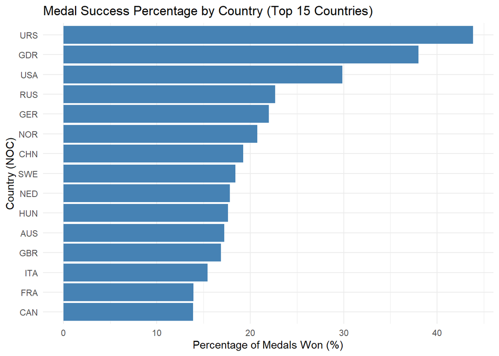

**The chart shows that medal chances change by country**

*URS and GDR show the highest success rates, reaching around 40%, meaning they earned medals in a large share of the events they entered*.

*USA is next at about 30%, followed by RUS and GER in the low 20s*.

*FRA and CAN are in the lower range, with success rates around 13–15%*.

## The Chi Square test

```
##
##  Pearson's Chi-squared test
##
## data:  crosstab_table
## X-squared = 4531.9, df = 14, p-value < 2.2e-16
```

**This result confirms what the bar chart already suggested:** *Countries like URS and GDR reach rates near 40%, while others stay around 13–15%. The data shows that success is not only about how many events a country enters, but that medal probability varies clearly from one country to another*

# Athletes and Sports

## Part 6.

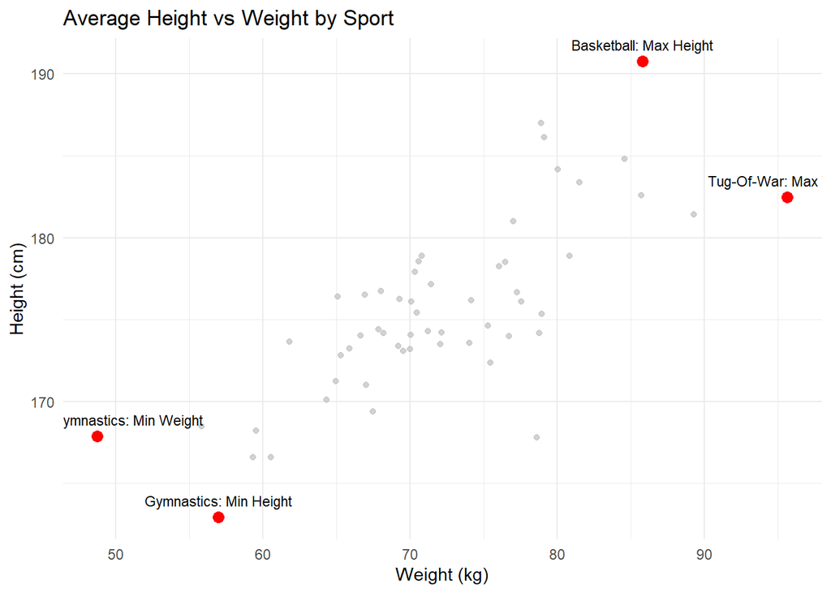

# Plot showing the number of medals

## Part 7.

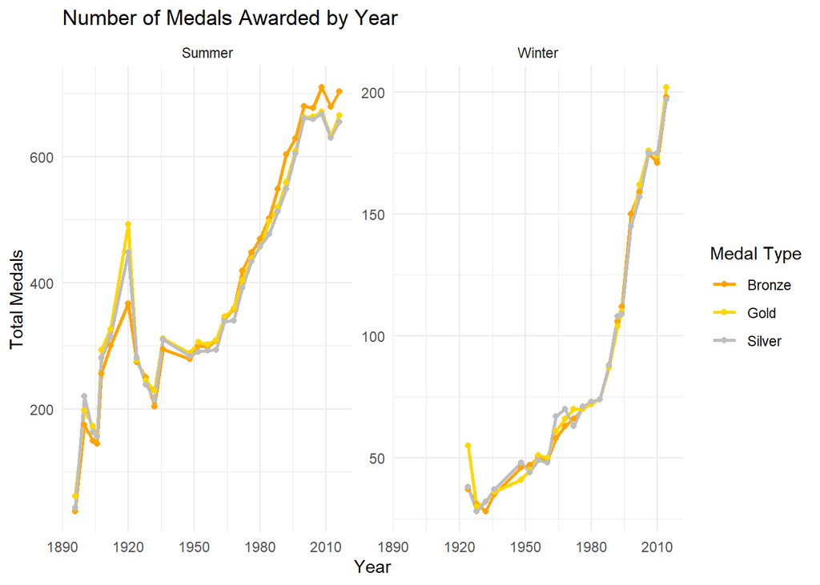